# GWAS Analysis Crypto Replication Series

```r
getwd()
```

```
## [1] "W:/Alan/crypto_GWAS/replication_series/QC_V3"
```

# Check Heterozygosity and Call rate

## Run these PLINK commands

#### Clean data and prune Hardy-Weinberg Outliers

/homes/athosnew/Genetics_Centre_Bioinformatics/resourses/plink_linux_x86_64/plink –file GSA2016_357_025 –geno 0.2 –maf 0.05 –hwe 0.001 –make-bed –out crypto_rep_clean

These samples had gender problems as had been incorretly assigned on the database. These have been corretced in FAM file now

## 44 HJHB027 HJHB027 1 2 PROBLEM -0.009479

## 101 HJHA041 HJHA041 2 1 PROBLEM 0.974100

## 108 HJHB024 HJHB024 1 2 PROBLEM -0.024620

## 180 HJHB031 HJHB031 2 1 PROBLEM 0.977100

These three samples TMHP002, HJHP009 and HJHP003 have doubts are to be removed before association analysis.

### update ID/SEX/Phenotype/data (FAM file) as per the information of Rae on the 20th March 2019.Recoded by Alan for PLINK format (1=Male; 2=Female; 1=Control; 2=Case)

#### Calculate Sample call rate

/homes/athosnew/Genetics_Centre_Bioinformatics/resourses/plink_linux_x86_64/plink –bfile crypto_rep_clean –missing -out Genotype_rates

#### Calculate heterozygosity

/homes/athosnew/Genetics_Centre_Bioinformatics/resourses/plink_linux_x86_64/plink –bfile crypto_rep_clean –het –out HetRates

#### Heterozygosity Vs % Missingness visialisations

#### Read in the genotype missingness data

```r
Call_rates <- as.data.frame(read.table("Genotype_rates.imiss", header = TRUE))
```

#### Read in the heterozygosity data

```r
HET_data <- as.data.frame(read.table("HetRates.het", header = TRUE))
```

#### Plot the % missingness versus the Heterozygosity rate (F score)

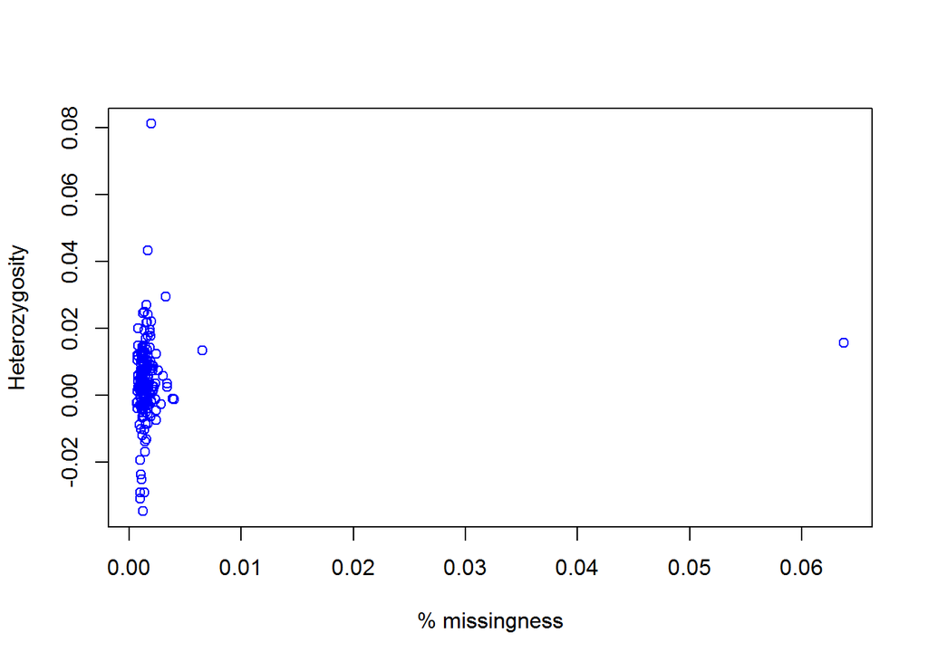

```r
plot(x = Call_rates$F_MISS, y = HET_data$F, xlab = "% missingness", ylab = "Heterozygosity", col = 4)
```

Generally excellent call rates. One sample; HJHA056 a bit lower than the others.

# Check Sex

## Run these PLINK commands

#### Clean data

/homes/athosnew/Genetics_Centre_Bioinformatics/resourses/plink_linux_x86_64/plink –file GSA2016_357_025 –geno 0.2 –maf 0.05 –make-bed –out crypto_rep_for_sex_check

#### check-sex

/homes/athosnew/Genetics_Centre_Bioinformatics/resourses/plink_linux_x86_64/plink –bfile crypto_rep_for_sex_check –check-sex 0.2 0.7 –out crypto_SexCheck

#### Read in the sex check data

```r
sex_data <- as.data.frame(read.table("crypto_SexCheck.sexcheck", header = TRUE))
```

#### Plot a histogram of the distributions of X chromosome F scores

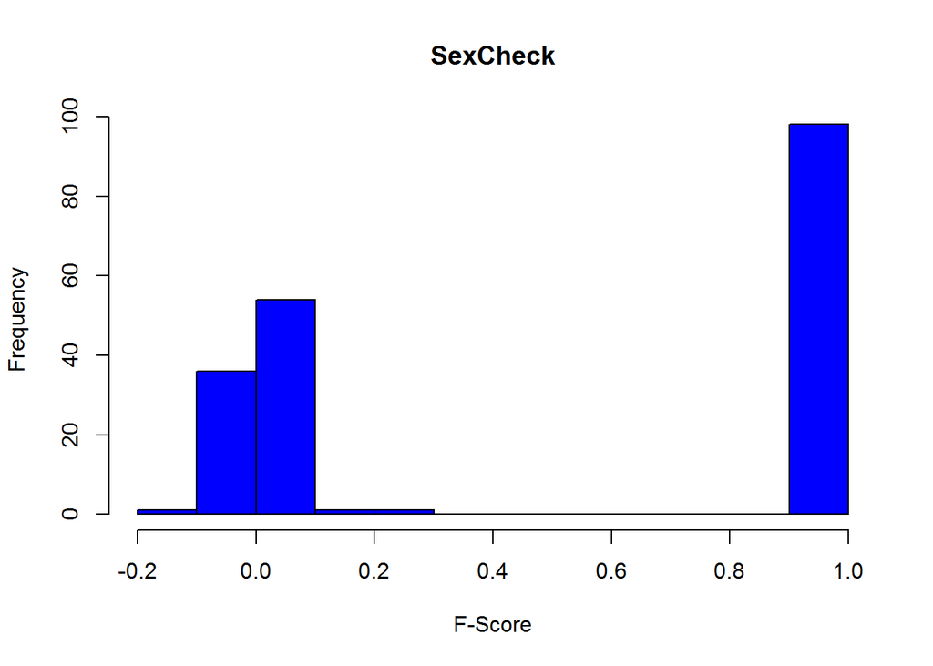

```r
hist(sex_data$F, col = "blue", xlab = "F-Score", main = "SexCheck")
```

#### Identify problem or wrong gender matching samples

```r
Gendermissmatches <- subset(sex_data, STATUS=="PROBLEM")
```

```r
Gendermissmatches
```

```
##         FID     IID PEDSEX SNPSEX  STATUS         F
## 30  TMHP002 TMHP002      2      1 PROBLEM 0.9727000
## 43  HJHP009 HJHP009      1      2 PROBLEM 0.0001059
## 115 HJHA004 HJHA004      2      0 PROBLEM 0.2014000
## 122 HJHP003 HJHP003      1      2 PROBLEM 0.0444400
```

As expected, there are 3 problematic samples from the SexCheck. TMHP002, HJHP009 and HJHP003 must be removed before doing the GWAS.

HJHA004 is boderline, but clearly a female and I would include in the present study.

# Principle Component Analysis

## Run these PLINK commands

Here we are merging our GWAS data with three Hapmap populations; CEU; Yoruban and HCB. Go back to the files that have have been pruned for HWE deviators.

#### extract_hapmap_snps

/homes/athosnew/Genetics_Centre_Bioinformatics/resourses/plink_linux_x86_64/plink –bfile crypto_rep_clean –extract /homes/athosnew/Genetics_Centre_Bioinformatics/resourses/Genome_reference_files/hapmap3r2_CEU.CHB.JPT.YRI.no-at-cg-snps.txt –make-bed –out crypto_rep_clean.hapmap-snps

#### remove_multi-alleleSNPS

/homes/athosnew/Genetics_Centre_Bioinformatics/resourses/plink_linux_x86_64/plink –bfile crypto_rep_clean.hapmap-snps –bmerge /homes/athosnew/Genetics_Centre_Bioinformatics/resourses/Genome_reference_files/hapmap3r2_CEU.CHB.JPT.YRI.founders.no-at-cg-snps_hg19_bad_snps_removed

/homes/athosnew/Genetics_Centre_Bioinformatics/resourses/plink_linux_x86_64/plink –bfile crypto_rep_clean.hapmap-snps –exclude plink.missnp –make-bed –out crypto_rep_clean.hapmap-snps-snps2

/homes/athosnew/Genetics_Centre_Bioinformatics/resourses/plink_linux_x86_64/plink –bfile crypto_rep_clean.hapmap-snps-snps2 –bmerge /homes/athosnew/Genetics_Centre_Bioinformatics/resourses/Genome_reference_files/hapmap3r2_CEU.CHB.JPT.YRI.founders.no-at-cg-snps_hg19_bad_snps_removed –out crypto_rep_clean_for_PCA

#### remove missing data here ### very important !!!!

/homes/athosnew/Genetics_Centre_Bioinformatics/resourses/plink_linux_x86_64/plink –bfile crypto_rep_clean_for_PCA –geno 0.05 –make-bed –out crypto_rep_clean_for_PCA_genopruned

#### GCTA_PCA_analysis

/homes/athosnew/Genetics_Centre_Bioinformatics/resourses/gcta_1.91.5beta/gcta64 –bfile crypto_rep_clean_for_PCA_genopruned –make-grm –autosome –thread-num 10 –out crypto_rep_clean_for_PCA_genopruned_matrix

/homes/athosnew/Genetics_Centre_Bioinformatics/resourses/gcta_1.91.5beta/gcta64 –grm crypto_rep_clean_for_PCA_genopruned_matrix –pca 4 –out crypto_rep_clean_for_PCA_genopruned_matrix_HapMap_PCA

#### Read in .csv file from GCTA package

```r
PCAdata <- as.data.frame(read.table("crypto_rep_clean_for_PCA_genopruned_matrix_HapMap_PCA.eigenvec", header = FALSE))
```

#### View the top of the table

```r
head(PCAdata)
```

```
##     V1      V2         V3        V4          V5          V6
## 1 1328 NA06984 -0.0287804 0.0788575 0.000289997  0.01040260
## 2 1328 NA06989 -0.0284167 0.0801490 0.001163800 -0.00655014
## 3 1330 NA12340 -0.0280670 0.0814637 0.006923440 -0.00219270
## 4 1330 NA12341 -0.0276128 0.0795317 0.003901190 -0.00133674
## 5 1330 NA12342 -0.0277068 0.0806625 0.001556900 -0.00454713
## 6 1330 NA12343 -0.0277385 0.0791792 0.002820910  0.00611213
```

#### Now plot PC1 and PC2

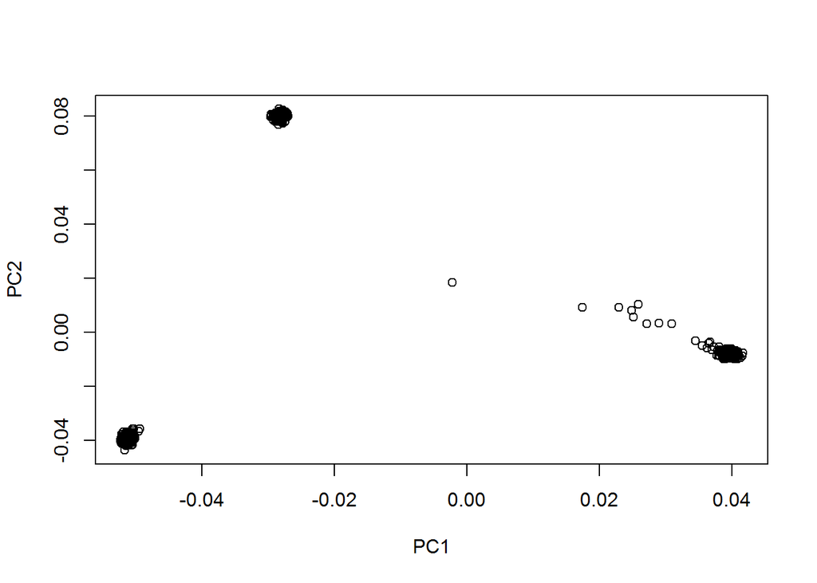

```r
plot(x = PCAdata$V3, y = PCAdata$V4,  xlab = "PC1", ylab = "PC2")
```

Or the file can be modified to have another column so that each population group is assigned a number so that the scatter plot can be colour co-ordinated

```r
PCAdata_mod <- as.data.frame(read.table("crypto_rep_clean_for_PCA_genopruned_matrix_HapMap_PCA.eigenvec_mod", header = FALSE))
```

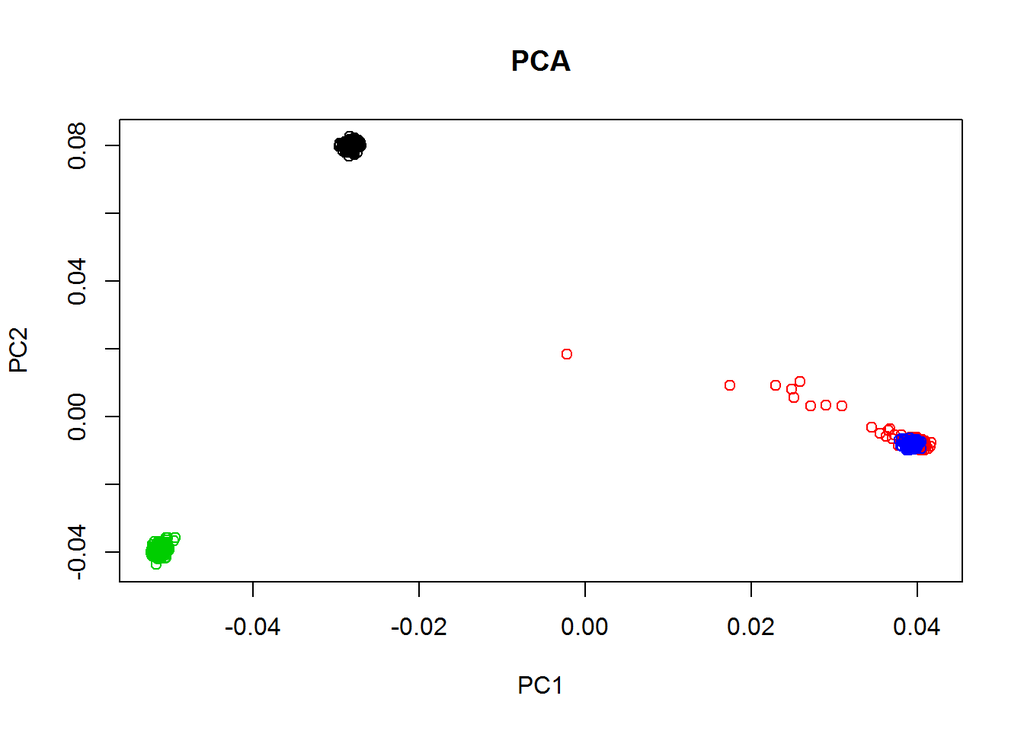

```r
plot(x = PCAdata_mod$V3, y = PCAdata_mod$V4, main = "PCA",  xlab = "PC1", ylab = "PC2", col = PCAdata_mod$V7)
```

# Principle Component Analysis of Cases and Controls and the Yorubans

exclude the HCB and the CEU population and re evaluate the PCA - also colour code the cases and controls differently.

#### In plink retain only samples that we want

/homes/athosnew/Genetics_Centre_Bioinformatics/resourses/plink_linux_x86_64/plink –bfile crypto_rep_clean_for_PCA_genopruned –keep my_keepers.txt –make-bed –out crypto_rep_clean_for_PCA_genopruned_case_control

#### GCTA_PCA_analysis_again

/homes/athosnew/Genetics_Centre_Bioinformatics/resourses/gcta_1.91.5beta/gcta64 –bfile crypto_rep_clean_for_PCA_genopruned_case_control –make-grm –autosome –thread-num 10 –out crypto_rep_clean_for_PCA_genopruned_case_control_matrix

/homes/athosnew/Genetics_Centre_Bioinformatics/resourses/gcta_1.91.5beta/gcta64 –grm crypto_rep_clean_for_PCA_genopruned_case_control_matrix –pca 4 –out crypto_rep_clean_for_PCA_genopruned_matrix_HapMap_PCA_case_control

```r
PCAdata_case_controls_mod <- as.data.frame(read.table("crypto_rep_clean_for_PCA_genopruned_matrix_HapMap_PCA_case_control.eigenvec_mod", header = FALSE))
```

```r
plot.new()
```

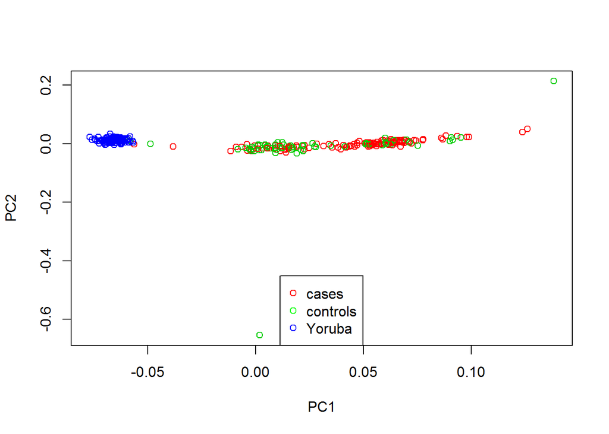

```r
plot(x = PCAdata_case_controls_mod$V3, y = PCAdata_case_controls_mod$V4,  xlab = "PC1", ylab = "PC2", col = PCAdata_case_controls_mod$V7)
legend(x="bottom", legend = c("cases", "controls", "Yoruba"), col = c("red", "green", "blue" ), pch = 1)
```

Cases and controls seem to cluster together, but there is a bit of a spread. Should we include PCAs as covariates in the analysis?

# Principle Component Analysis of Cases and Controls ONLY

exclude all HapMap populations and re evaluate the PCA - also colour code the cases and controls differently.

#### In plink retain only samples that we want

/homes/athosnew/Genetics_Centre_Bioinformatics/resourses/plink_linux_x86_64/plink –bfile crypto_rep_clean_for_PCA_genopruned –keep my_keepers1.txt –make-bed –out crypto_rep_clean_for_PCA_genopruned_case_control1

#### GCTA_PCA_analysis_again

/homes/athosnew/Genetics_Centre_Bioinformatics/resourses/gcta_1.91.5beta/gcta64 –bfile crypto_rep_clean_for_PCA_genopruned_case_control1 –make-grm –autosome –thread-num 10 –out crypto_rep_clean_for_PCA_genopruned_case_control1_matrix

/homes/athosnew/Genetics_Centre_Bioinformatics/resourses/gcta_1.91.5beta/gcta64 –grm crypto_rep_clean_for_PCA_genopruned_case_control1_matrix –pca 4 –out crypto_rep_clean_for_PCA_genopruned_matrix_HapMap_PCA_case_control1

```r
PCAdata_case_controls_mod1 <- as.data.frame(read.table("crypto_rep_clean_for_PCA_genopruned_matrix_HapMap_PCA_case_control1.eigenvec_mod", header = FALSE))
```

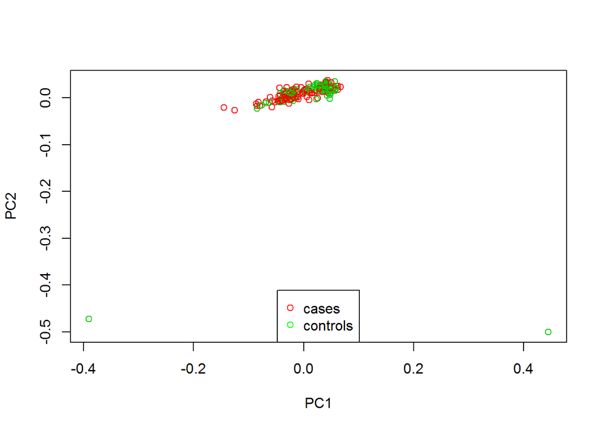

```r
plot(x = PCAdata_case_controls_mod1$V3, y = PCAdata_case_controls_mod1$V4,  xlab = "PC1", ylab = "PC2", col = PCAdata_case_controls_mod1$V7)
legend(x="bottom", legend = c("cases", "controls"), col = c("red", "green"), pch = 1)
```

Here we will check for outliers:

```r
PCAdata_case_controls_mod1[which(PCAdata_case_controls_mod1$V3> 0.4),]
```

```
##          V1      V2       V3        V4       V5        V6 V7
## 60  HJHB005 HJHB005 0.444476 -0.500572 0.202357 0.0371014  2
## 184 TMHP002 TMHP002 0.444413 -0.500579 0.202295 0.0369143  3
```

```r
PCAdata_case_controls_mod1[which(PCAdata_case_controls_mod1$V3< -0.2),]
```

```
##          V1      V2        V3        V4        V5         V6 V7
## 61  HJHB006 HJHB006 -0.390155 -0.472866 -0.324858 -0.0895386  2
## 183 TMHP001 TMHP001 -0.390214 -0.472861 -0.324865 -0.0896735  3
```

Thus we will need to remove the follwoing outlier samples:

HJHB005 (control) TMHP002 (case) HJHB006 (control) TMHP001 (case)

# Checking Sample relatedness

#### prune_LD_SNPS

/homes/athosnew/Genetics_Centre_Bioinformatics/resourses/plink_linux_x86_64/plink –bfile crypto_rep_clean –indep-pairwise 50 5 0.5 –out crypto_rep_clean_prune ####use only RS numbers here! awk ‘$1 ~ /^rs/’ crypto_rep_clean_prune.prune.in > crypto_rep_clean_prune.prune.in1

/homes/athosnew/Genetics_Centre_Bioinformatics/resourses/plink_linux_x86_64/plink –bfile crypto_rep_clean –extract crypto_rep_clean_prune.prune.in1 –make-bed –out crypto_rep_clean_PRUNED

#### IBD calculation

/homes/athosnew/Genetics_Centre_Bioinformatics/resourses/plink_linux_x86_64/plink –bfile crypto_rep_clean_PRUNED –genome –min 0.06 –out crypto_rep_clean_PRUNED_IBD

```r
Identity_by_descent <- as.data.frame(read.table("crypto_rep_clean_PRUNED_IBD.genome", header = TRUE))
```

```r
Identity_by_descent
```

```
##      FID1    IID1    FID2    IID2 RT EZ Z0 Z1 Z2 PI_HAT PHE      DST PPC
## 1 TMHP002 TMHP002 HJHB005 HJHB005 UN NA  0  0  1      1   0 0.999997   1
## 2 HJHB006 HJHB006 TMHP001 TMHP001 UN NA  0  0  1      1   0 0.999995   1
##   RATIO
## 1    NA
## 2    NA
```

These sample pairs are duplicates of one another : IBD = 1

TMHP002 HJHB005 HJHB006 TMHP001

one (or all) should be removed from the study

# merging the data with the original series

#### Merge chromosome PLINK files from Schichina

/homes/athosnew/Genetics_Centre_Bioinformatics/resourses/plink_linux_x86_64/plink –merge-list files_to_merge.txt –make-bed –out original_crypto_series –allow-no-sex

#### first pass to merge with new dataset

crypto_rep_clean original_crypto_series

/homes/athosnew/Genetics_Centre_Bioinformatics/resourses/plink_linux_x86_64/plink –bfile crypto_rep_clean –bmerge original_crypto_series –make-bed –out phase1_2_merged

Error: 17512 variants with 3+ alleles present. * If you believe this is due to strand inconsistency, try –flip with phase1_2_merged-merge.missnp.

#### fix strand errors

To check for strand errors, you can do a ‘trial flip’. Note the number of merge errors, use –flip with one of the source files and the .missnp file, and retry the merge. If most of the errors disappear, you probably do have strand errors, and you can use –flip on the second .missnp file to ‘un-flip’ any other errors. For example:

/homes/athosnew/Genetics_Centre_Bioinformatics/resourses/plink_linux_x86_64/plink –bfile crypto_rep_clean –flip phase1_2_merged-merge.missnp –make-bed –out crypto_rep_clean_trial

/homes/athosnew/Genetics_Centre_Bioinformatics/resourses/plink_linux_x86_64/plink –bfile original_crypto_series –bmerge crypto_rep_clean_trial –make-bed –out merged_trial –allow-no-sex

No further missnips were identified, but we need to look for C/G A/T errors with flipscan.

#### remove possible problematic C/G A/T snps

If the first .missnp file did contain strand errors, it probably did not contain all of them. After you’re done with the basic merge, use –flip-scan to catch the A/T and C/G SNP flips that slipped through (using –make-pheno to temporarily redefine ‘case’ and ‘control’ if necessary):

/homes/athosnew/Genetics_Centre_Bioinformatics/resourses/plink_linux_x86_64/plink –bfile original_crypto_series –flip-scan –out original_crypto_series

/homes/athosnew/Genetics_Centre_Bioinformatics/resourses/plink_linux_x86_64/plink –bfile crypto_rep_clean –flip-scan –out flipscan_crypto_clean

Need to remove the variants that have a negative LD match detected with flipscan (flipscan_crypto_clean.flipscan)

As C/G and A/T snps may still pose a problem, identify the C/G and A/T snps and remove them from the final dataset: (C_G_and_A_T_snp_consider_take away.txt)

/homes/athosnew/Genetics_Centre_Bioinformatics/resourses/plink_linux_x86_64/plink –bfile original_crypto_series –bmerge crypto_rep_clean_trial –make-bed –out merged_tmp –allow-no-sex

/homes/athosnew/Genetics_Centre_Bioinformatics/resourses/plink_linux_x86_64/plink –bfile merged_tmp –exclude C_G_and_A_T_snp_consider_take away.txt –make-bed –out crypto_merged_for_imputation –allow-no-sex

merged data should now bw fine and ready for analysis and imputation

#### extract_hapmap_snps

/homes/athosnew/Genetics_Centre_Bioinformatics/resourses/plink_linux_x86_64/plink –bfile crypto_merged_for_imputation –extract /homes/athosnew/Genetics_Centre_Bioinformatics/resourses/Genome_reference_files/hapmap3r2_CEU.CHB.JPT.YRI.no-at-cg-snps.txt –make-bed –out crypto_rep_merged_clean.hapmap-snps

#### remove_multi-alleleSNPS

/homes/athosnew/Genetics_Centre_Bioinformatics/resourses/plink_linux_x86_64/plink –bfile crypto_rep_merged_clean.hapmap-snps –bmerge /homes/athosnew/Genetics_Centre_Bioinformatics/resourses/Genome_reference_files/hapmap3r2_CEU.CHB.JPT.YRI.founders.no-at-cg-snps_hg19_bad_snps_removed

/homes/athosnew/Genetics_Centre_Bioinformatics/resourses/plink_linux_x86_64/plink –bfile crypto_rep_merged_clean.hapmap-snps –exclude plink.missnp –make-bed –out crypto_rep_merged_clean.hapmap-snps-snps2

/homes/athosnew/Genetics_Centre_Bioinformatics/resourses/plink_linux_x86_64/plink –bfile crypto_rep_merged_clean.hapmap-snps-snps2 –bmerge /homes/athosnew/Genetics_Centre_Bioinformatics/resourses/Genome_reference_files/hapmap3r2_CEU.CHB.JPT.YRI.founders.no-at-cg-snps_hg19_bad_snps_removed –out crypto_rep_merged_clean_for_PCA

#### remove missing data here ### very important !!!!

/homes/athosnew/Genetics_Centre_Bioinformatics/resourses/plink_linux_x86_64/plink –bfile crypto_rep_merged_clean_for_PCA –geno 0.05 –make-bed –out crypto_rep_merged_clean_for_PCA_genopruned

#### In plink retain only samples that we want

/homes/athosnew/Genetics_Centre_Bioinformatics/resourses/plink_linux_x86_64/plink –bfile crypto_rep_merged_clean_for_PCA_genopruned –keep my_keepers.txt –make-bed –out crypto_rep_merged_clean_for_PCA_genopruned1

#### GCTA_PCA_analysis

/homes/athosnew/Genetics_Centre_Bioinformatics/resourses/gcta_1.91.5beta/gcta64 –bfile crypto_rep_merged_clean_for_PCA_genopruned1 –make-grm –autosome –thread-num 10 –out crypto_rep_merged_clean_for_PCA_genopruned_matrix

/homes/athosnew/Genetics_Centre_Bioinformatics/resourses/gcta_1.91.5beta/gcta64 –grm crypto_rep_merged_clean_for_PCA_genopruned_matrix –pca 4 –out crypto_rep_merged_clean_for_PCA_genopruned_matrix_HapMap_PCA

#### Read in .csv file from GCTA package

```r
setwd("W:/Alan/crypto_GWAS/Merged_PCA")
PCAdata_all_merged <- as.data.frame(read.table("crypto_rep_merged_clean_for_PCA_genopruned_matrix_HapMap_PCA.eigenvec_mod", header = FALSE))
```

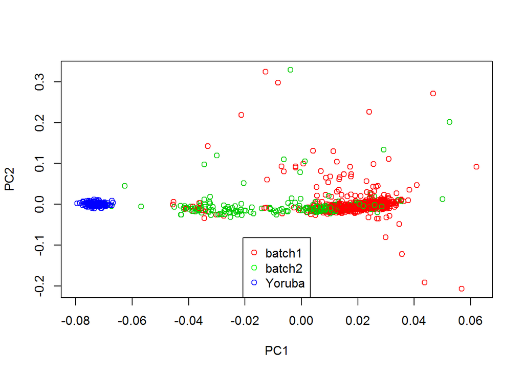

```r
plot(x = PCAdata_all_merged$V3, y = PCAdata_all_merged$V4,  xlab = "PC1", ylab = "PC2", col = PCAdata_all_merged$V7)
legend(x="bottom", legend = c("batch1", "batch2", "Yoruba"), col = c("red", "green", "blue" ), pch = 1)
```

#### And now plot with all worldwide populations:

#### remove missing data here ### very important !!!!

/homes/athosnew/Genetics_Centre_Bioinformatics/resourses/plink_linux_x86_64/plink –bfile crypto_rep_merged_clean_for_PCA –geno 0.05 –make-bed –out crypto_rep_merged_clean_for_PCA_genopruned

#### GCTA_PCA_analysis

/homes/athosnew/Genetics_Centre_Bioinformatics/resourses/gcta_1.91.5beta/gcta64 –bfile crypto_rep_merged_clean_for_PCA_genopruned –make-grm –autosome –thread-num 10 –out crypto_rep_merged_clean_for_PCA_genopruned_matrix

/homes/athosnew/Genetics_Centre_Bioinformatics/resourses/gcta_1.91.5beta/gcta64 –grm crypto_rep_merged_clean_for_PCA_genopruned_matrix –pca 4 –out crypto_rep_merged_clean_for_PCA_genopruned_matrix_HapMap_PCA_all

#### Read in .csv file from GCTA package

```r
setwd("W:/Alan/crypto_GWAS/Merged_PCA")
PCAdata_all_merged_allpops <- as.data.frame(read.table("crypto_rep_merged_clean_for_PCA_genopruned_matrix_HapMap_PCA_all.eigenvec_mod", header = FALSE))
```

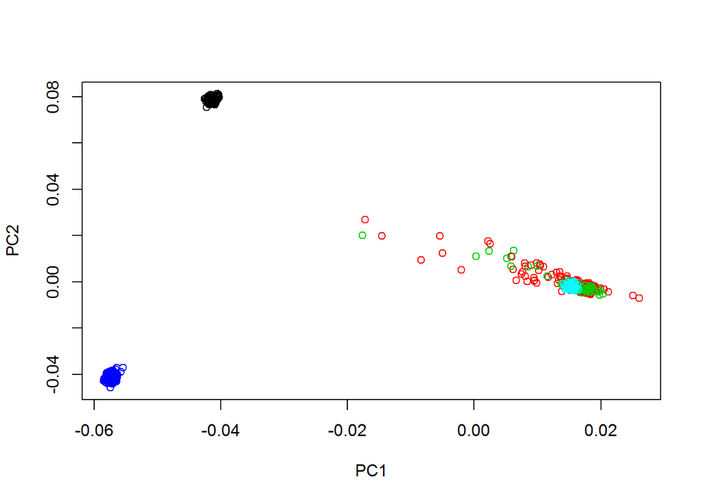

```r
plot(x = PCAdata_all_merged_allpops$V3, y = PCAdata_all_merged_allpops$V4,  xlab = "PC1", ylab = "PC2", col = PCAdata_all_merged_allpops$V7)
```

#### ..and finally just our two cohorts:

#### remove missing data here ### very important !!!!

/homes/athosnew/Genetics_Centre_Bioinformatics/resourses/plink_linux_x86_64/plink –bfile crypto_rep_merged_clean_for_PCA –geno 0.05 –make-bed –out crypto_rep_merged_clean_for_PCA_genopruned

#### In plink retain only samples that we want

/homes/athosnew/Genetics_Centre_Bioinformatics/resourses/plink_linux_x86_64/plink –bfile crypto_rep_merged_clean_for_PCA_genopruned –keep my_keepers1.txt –make-bed –out crypto_rep_merged_clean_for_PCA_genopruned2

#### GCTA_PCA_analysis

/homes/athosnew/Genetics_Centre_Bioinformatics/resourses/gcta_1.91.5beta/gcta64 –bfile crypto_rep_merged_clean_for_PCA_genopruned2 –make-grm –autosome –thread-num 10 –out crypto_rep_merged_clean_for_PCA_genopruned_matrix2

/homes/athosnew/Genetics_Centre_Bioinformatics/resourses/gcta_1.91.5beta/gcta64 –grm crypto_rep_merged_clean_for_PCA_genopruned_matrix2 –pca 4 –out crypto_rep_merged_clean_for_PCA_genopruned_matrix_HapMap_PCA2

```r
setwd("W:/Alan/crypto_GWAS/Merged_PCA")
PCAdata_all_merged_only_cohorts <- as.data.frame(read.table("crypto_rep_merged_clean_for_PCA_genopruned_matrix_HapMap_PCA2.eigenvec_mod", header = FALSE))
```

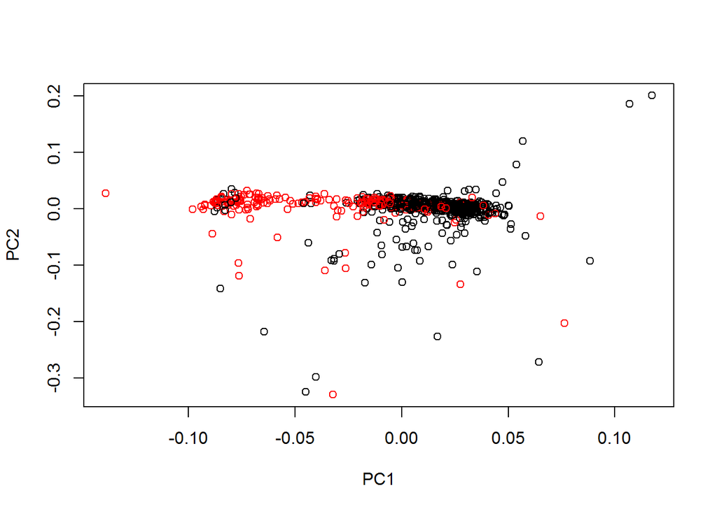

```r
plot(x = PCAdata_all_merged_only_cohorts$V3, y = PCAdata_all_merged_only_cohorts$V4,  xlab = "PC1", ylab = "PC2", col = PCAdata_all_merged_only_cohorts$V7)
```